# Homework_07

### Altering the metrics of the fake data to see how the parameters affect statistical significance

```r
#Double the mean of the South Main Lake fake data
set.seed(100)
nGroup <- 3
nName <- c("North Main Lake", "Central Main Lake", "South Main Lake")
nSize <- c(72, 218, 55)
nMean2 <- c(100.4, 90.1, 109.8)
nSD <- c(199.7, 169.8, 119.2)
ID <- 1:(sum(nSize))

meanDubCPUE <- c(rtruncnorm(n=nSize[1], a = 0, b = Inf, mean=nMean2[1],sd=nSD[1]),
            rtruncnorm(n=nSize[2], a = 0, b = Inf, mean=nMean2[2],sd=nSD[2]),
            rtruncnorm(n=nSize[3], a = 0, b = Inf, mean=nMean2[3],sd=nSD[3]))
TGroup <- rep(nName,nSize)
ANOMeanDubdata <- data.frame(ID,TGroup,meanDubCPUE)

ANOMeanDubdata$TGroup <- factor(ANOMeanDubdata$TGroup, levels = c("North Main Lake", "Central Main Lake", "South Main Lake"))

#Run ANOVA and Tukey on doubled South Main Lake mean data

ANOMeanDubmodel <- aov(meanDubCPUE~TGroup,data=ANOMeanDubdata)
summary(ANOMeanDubmodel)
```

```
##              Df  Sum Sq Mean Sq F value Pr(>F)
## TGroup        2   82514   41257   2.795 0.0625 .
## Residuals   342 5047412   14759
## ---
## Signif. codes:  0 '***' 0.001 '**' 0.01 '*' 0.05 '.' 0.1 ' ' 1
```

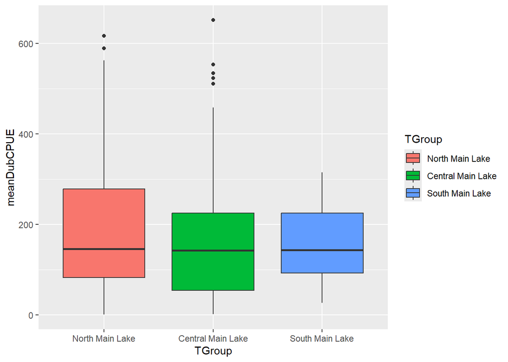

```r
ANOMeanDubPlot <- ggplot(data=ANOMeanDubdata,aes(x=TGroup,y=meanDubCPUE,fill=TGroup)) +
  geom_boxplot()
print(ANOMeanDubPlot)
```

```r
TukeyHSD(ANOMeanDubmodel)
```

```
##   Tukey multiple comparisons of means
##     95% family-wise confidence level
##
## Fit: aov(formula = meanDubCPUE ~ TGroup, data = ANOMeanDubdata)
##
## $TGroup
##                                         diff       lwr       upr     p adj
## Central Main Lake-North Main Lake -37.633399 -76.50438  1.237585 0.0601281
## South Main Lake-North Main Lake   -39.548020 -90.76044 11.664400 0.1652668
## South Main Lake-Central Main Lake  -1.914621 -45.06581 41.236567 0.9940039
```

In order for there to be no statistical difference between the North Main Lake and the South Main Lake CPUEs I had to double the original mean of the South Main Lake.

```r
#Change the sample sizes
set.seed(110)
nGroup <- 3
nName <- c("North Main Lake", "Central Main Lake", "South Main Lake")
nSize2 <- c(72, 218, 15)
nMean <- c(100.4, 90.1, 54.9)
nSD <- c(199.7, 169.8, 119.2)
ID <- 1:(sum(nSize2))

sizeCPUE <- c(rtruncnorm(n=nSize2[1], a = 0, b = Inf, mean=nMean[1],sd=nSD[1]),
            rtruncnorm(n=nSize2[2], a = 0, b = Inf, mean=nMean[2],sd=nSD[2]),
            rtruncnorm(n=nSize2[3], a = 0, b = Inf, mean=nMean[3],sd=nSD[3]))
TGroup <- rep(nName,nSize2)
ANOSizedata <- data.frame(ID,TGroup,sizeCPUE)

ANOSizedata$TGroup <- factor(ANOSizedata$TGroup, levels = c("North Main Lake", "Central Main Lake", "South Main Lake"))

#Run ANOVA and Tukey on altered sample size data

ANOSizemodel <- aov(sizeCPUE~TGroup,data=ANOSizedata)
summary(ANOSizemodel)
```

```
##              Df  Sum Sq Mean Sq F value  Pr(>F)
## TGroup        2  144287   72144   5.492 0.00454 **
## Residuals   302 3967165   13136
## ---
## Signif. codes:  0 '***' 0.001 '**' 0.01 '*' 0.05 '.' 0.1 ' ' 1
```

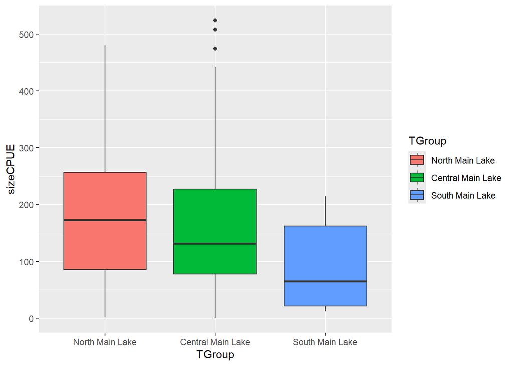

```r
ANOSizePlot <- ggplot(data=ANOSizedata,aes(x=TGroup,y=sizeCPUE,fill=TGroup)) +
  geom_boxplot()
print(ANOSizePlot)
```

```r
TukeyHSD(ANOSizemodel)
```

```
##   Tukey multiple comparisons of means
##     95% family-wise confidence level
##
## Fit: aov(formula = sizeCPUE ~ TGroup, data = ANOSizedata)
##
## $TGroup
##                                         diff        lwr         upr     p adj
## Central Main Lake-North Main Lake  -31.95289  -68.64668   4.7408994 0.1020220
## South Main Lake-North Main Lake   -103.02700 -179.64588 -26.4081134 0.0048182
## South Main Lake-Central Main Lake  -71.07411 -143.13376   0.9855457 0.0541551
```

In order for there to be no statistical difference between the Central Main Lake and the South Main Lake CPUEs (largest sample size difference) I had to reduce the South Main Lake sample size by 40 to 15.